# A3_skobsar

Stefanie Kobsar

5/21/2020

1.1. Modelo de regresión lineal univariante

```r
df_bw <-  read.csv("BWprocessed.csv")
head(df_bw)
```

```
##   ID                           HP      City  Time          Day   BW BPD
## 1  1 H.G.U.Gregorio Mara\xf1\xf3n    Madrid 13:20      Viernes 2200  82
## 2  2             H.U.de Bellvitge Barcelona 11:00        Lunes 4100  97
## 3  3             H.U.de Bellvitge Barcelona 00:00       Martes 4200  97
## 4  4                  H.Cl\xednic Barcelona 18:38       Jueves 1300  74
## 5  5            H.U.12 de octubre    Madrid 09:53 Mi\xe9rcoles 1150  68
## 6  6 H.G.U.Gregorio Mara\xf1\xf3n    Madrid 05:40    S\xe1bado 3400  94
##    AD Sex Ge Sm
## 1  90   M 33  N
## 2 129   M 43  N
## 3 133   F 43  N
## 4  71   M 33  S
## 5  80   F 33  S
## 6 110   F 39  N
```

##### REGRESIÓN LINEAL

Se representa la variables peso del bebé en función del diámetro abdominal. Se representa un diagrama de dispersión de ambas variables para poder determinar gráficamente la recta de ajuste y evaluar la bondad del mismo.

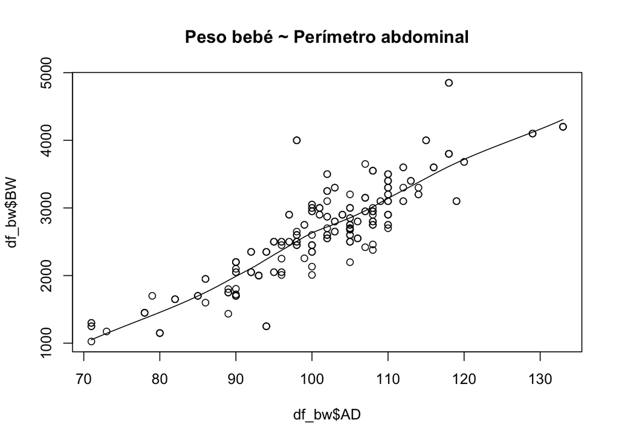

```r
scatter.smooth(x=df_bw$AD, y=df_bw$BW, main="Peso bebé ~ Perímetro abdominal")  # scatterplot
```

Se observa que puede existir una correlación lineal entre las dos variables. Para confirmarlo, hay que obtener los coeficientes de la recta de ajuste y el valor de R^2, que determina la calidad del ajuste. Se considera un buen ajuste a partir de R^2 >=0,90.

```r
linearMod <- lm(AD ~ BW, data=df_bw)
print(linearMod)
```

```
##
## Call:
## lm(formula = AD ~ BW, data = df_bw)
##
## Coefficients:
## (Intercept)           BW
##    65.27981      0.01341
```

Se ha obtenido una recta de ajuste de la forma y = 0,01341x + 65,27981.

```r
summary(linearMod)
```

```
##
## Call:
## lm(formula = AD ~ BW, data = df_bw)
##
## Residuals:
##     Min      1Q  Median      3Q     Max
## -20.928  -3.537   0.249   3.157  12.143
##
## Coefficients:
##              Estimate Std. Error t value Pr(>|t|)
## (Intercept) 6.528e+01  1.188e+00   54.94   <2e-16 ***
## BW          1.341e-02  4.294e-04   31.23   <2e-16 ***
## ---
## Signif. codes:  0 '***' 0.001 '**' 0.01 '*' 0.05 '.' 0.1 ' ' 1
##
## Residual standard error: 5.65 on 298 degrees of freedom
## Multiple R-squared:  0.766,  Adjusted R-squared:  0.7652
## F-statistic: 975.5 on 1 and 298 DF,  p-value: < 2.2e-16
```

El valor predicitivo de la recta obtenida podría ser mejorado con el análisis y descarte (siempre que sea posible) de los outliers.

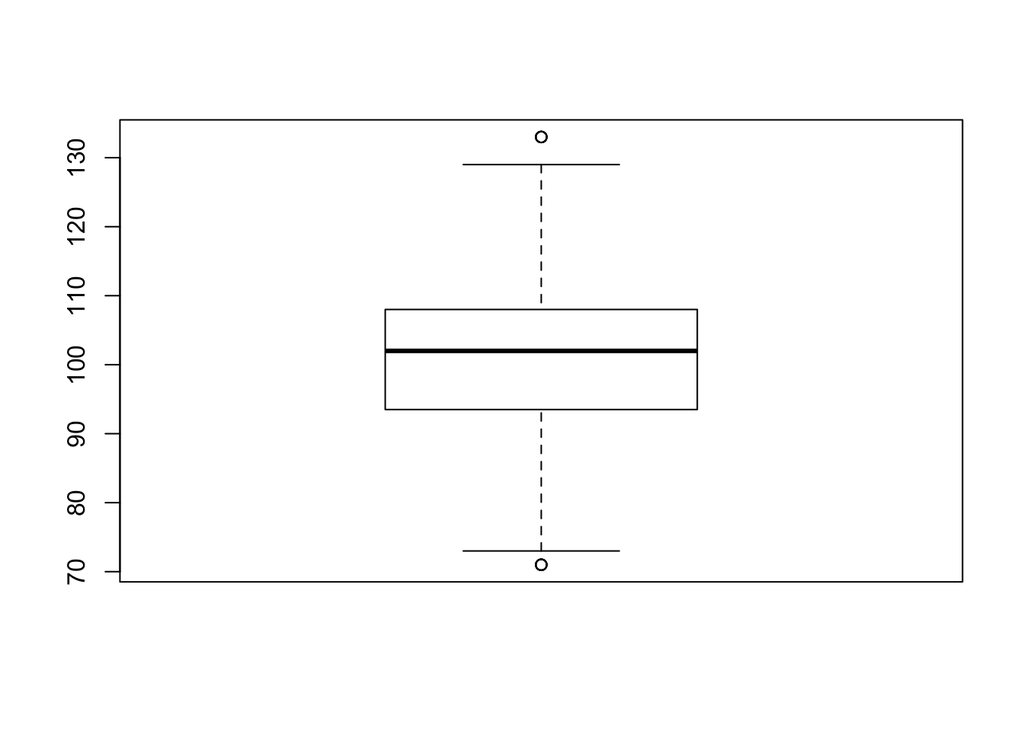

```r
boxplot(df_bw$AD)
```

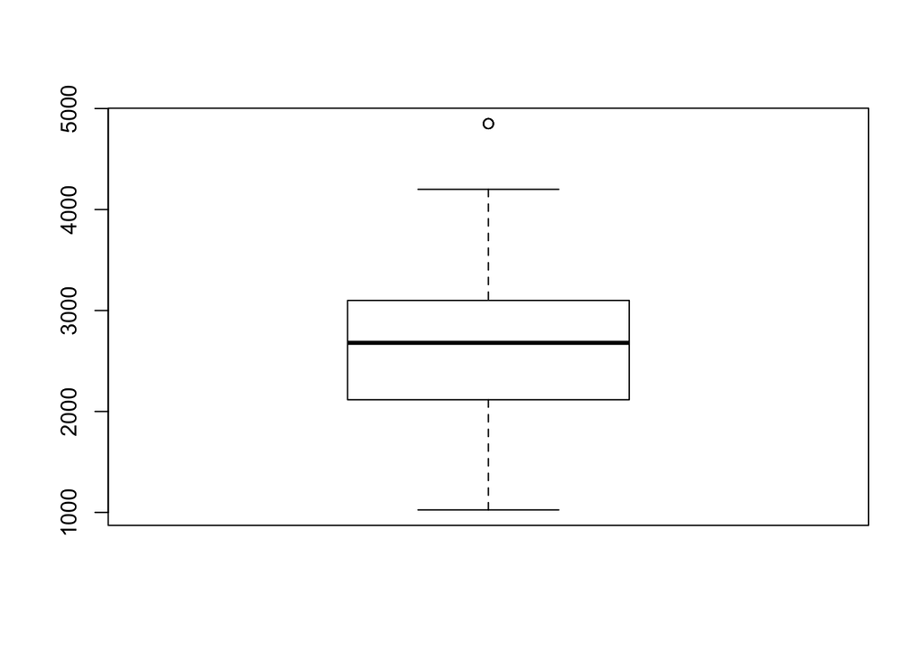

```r
boxplot(df_bw$BW)
```

Los valores del set de datos se consideran extremos (outliers) cuando están fuera del rango en una proporción de 1.5 veces del rango formado por los cuartiles más externos. Para valorar si es correcto eliminar los ouliers, hay que evaluar si es estadísitcamente correcto. Para ello existen múltiples tests, y en este caso se usará el test de grubbs para realizar la evaluación.

```r
library(outliers)

grubbs.test(df_bw$AD)
```

```
##
##  Grubbs test for one outlier
##
## data:  df_bw$AD
## G = 2.74718, U = 0.97467, p-value = 0.8604
## alternative hypothesis: highest value 133 is an outlier
```

```r
grubbs.test(df_bw$BW)
```

```
##
##  Grubbs test for one outlier
##
## data:  df_bw$BW
## G = 2.87709, U = 0.97222, p-value = 0.5689
## alternative hypothesis: highest value 4850 is an outlier
```

```r
df_ad <- df_bw$AD
match(c(133),df_ad)
```

```
## [1] 3
```

```r
df_BW <- df_bw$BW
match(c(4850),df_BW)
```

```
## [1] 133
```

```r
df_outlier <- data.frame(df_BW, df_ad)
df_outlier_2 <- df_outlier[-c(3,133), ]
colnames(df_outlier_2) <- c("ADnew", "BWnew")
```

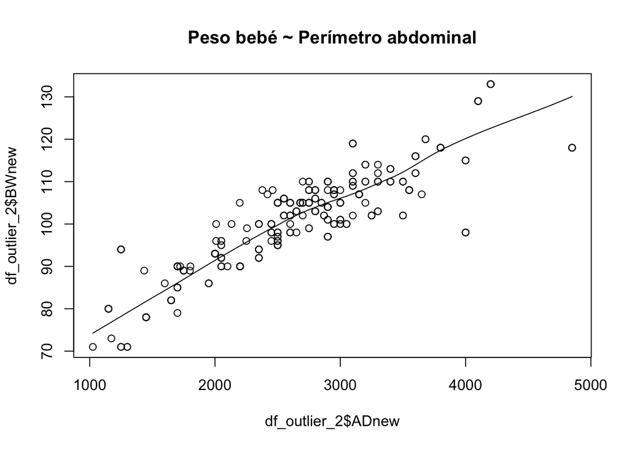

```r
scatter.smooth(x=df_outlier_2$ADnew, y=df_outlier_2$BWnew, main="Peso bebé ~ Perímetro abdominal")  # scatterplot
```

```r
linearMod_2 <- lm(ADnew ~ BWnew , data=df_outlier_2)
print(linearMod_2)
```

```
##
## Call:
## lm(formula = ADnew ~ BWnew, data = df_outlier_2)
##
## Coefficients:
## (Intercept)        BWnew
##    -3079.18        56.82
```

Se ha obtenido una recta de ajuste de la forma y = 56,82x + -3079,18.

```r
summary(linearMod_2)
```

```
##
## Call:
## lm(formula = ADnew ~ BWnew, data = df_outlier_2)
##
## Residuals:
##      Min       1Q   Median       3Q      Max
## -1011.80  -207.89   -26.58   164.34  1510.93
##
## Coefficients:
##              Estimate Std. Error t value Pr(>|t|)
## (Intercept) -3079.177    185.546  -16.59   <2e-16 ***
## BWnew          56.819      1.829   31.07   <2e-16 ***
## ---
## Signif. codes:  0 '***' 0.001 '**' 0.01 '*' 0.05 '.' 0.1 ' ' 1
##
## Residual standard error: 362.7 on 296 degrees of freedom
## Multiple R-squared:  0.7653, Adjusted R-squared:  0.7645
## F-statistic: 965.2 on 1 and 296 DF,  p-value: < 2.2e-16
```

El ajuste mediante una recta de regresión se considera una buena primera aproximación ya que si que se puede observar una tendencia lineal, pero este tipo de ajuste no podemos considerarlo significativo ni concluyente de cara a construir un modelo predictivo ya que el valor de R^2 se queda lejos de ser aceptable para cumplir este propósito.

1.2. Modelo de regresión lineal múltiple (regresores cuantitativos)

1. Estimar por mínimos cuadrados ordinarios un modelo lineal que explique la variable peso del bebé en función del diámetro abdominal y el diámetro biparietal. Se procederá a evaluar la bondad de ajuste a través del coeficiente de determinación ajustado.

Discutir si se produce una mejora del modelo.

2. Estudiar la existencia o no de multicolinealidad entre las covariables del modelo anterior, AD y BPD.

Ya hemos visto que existe una tendencia lineal entre BW y AD en el scatter plot de más arriba. Se hace el mismo análisis para BW en función de BPD.

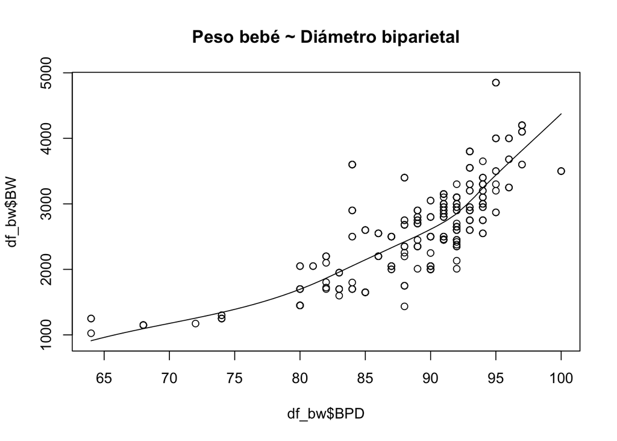

```r
scatter.smooth(x=df_bw$BPD, y=df_bw$BW, main="Peso bebé ~ Diámetro biparietal")  # scatterplot
```

Se observa una ligera tendencia exponencial en la relación de estas dos variables. A continuación se analiza una posible multicolinealidad entre las covariables

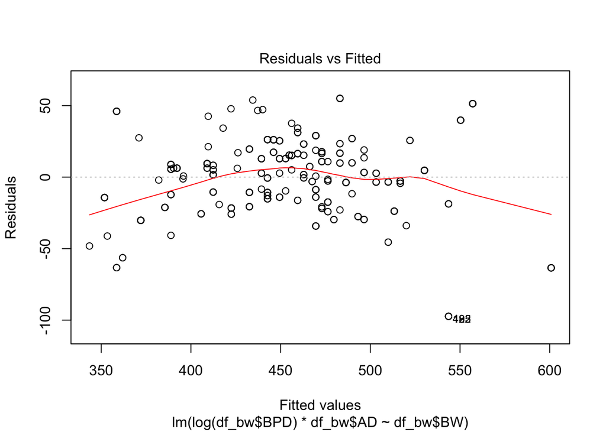

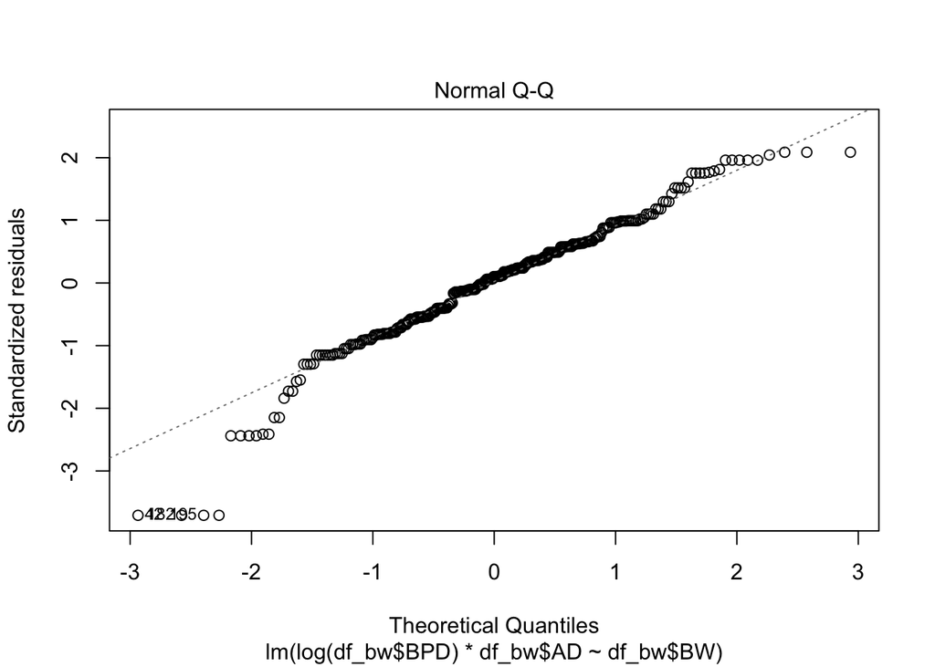

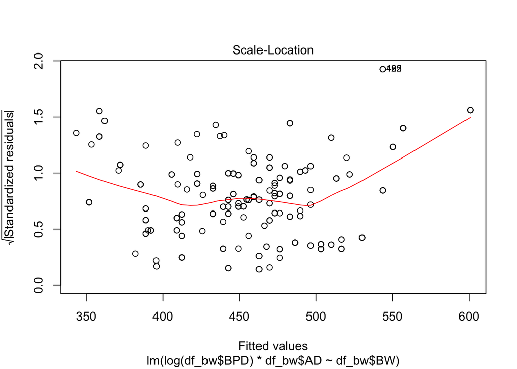

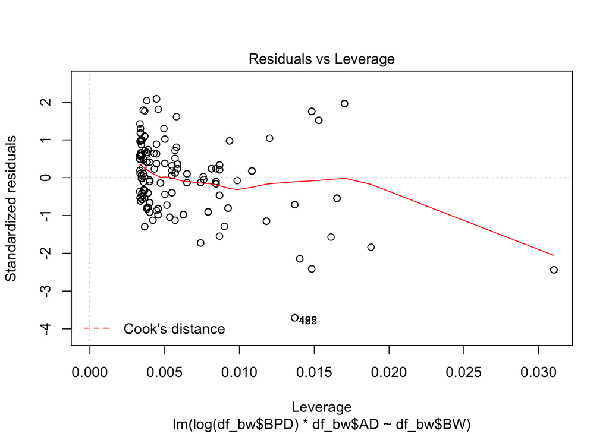

```r
model_multi <- lm(log(df_bw$BPD)*df_bw$AD ~ df_bw$BW, data = df_bw)
plot(model_multi)
```

```r
print(model_multi)
```

```
##
## Call:
## lm(formula = log(df_bw$BPD) * df_bw$AD ~ df_bw$BW, data = df_bw)
##
## Coefficients:
## (Intercept)     df_bw$BW
##   274.47547      0.06728
```

```r
summary(model_multi)
```

```
##
## Call:
## lm(formula = log(df_bw$BPD) * df_bw$AD ~ df_bw$BW, data = df_bw)
##
## Residuals:
##     Min      1Q  Median      3Q     Max
## -97.328 -15.201   2.701  16.419  55.040
##
## Coefficients:
##              Estimate Std. Error t value Pr(>|t|)
## (Intercept) 2.745e+02  5.558e+00   49.39   <2e-16 ***
## df_bw$BW    6.728e-02  2.008e-03   33.50   <2e-16 ***
## ---
## Signif. codes:  0 '***' 0.001 '**' 0.01 '*' 0.05 '.' 0.1 ' ' 1
##
## Residual standard error: 26.43 on 298 degrees of freedom
## Multiple R-squared:  0.7902, Adjusted R-squared:  0.7895
## F-statistic:  1122 on 1 and 298 DF,  p-value: < 2.2e-16
```

Se observa que la relación entres BW y la covariable AD-BPD ha incrementado la bondad del ajuste.

1.3. Modelo de regresión lineal múltiple (regresores cuantitativos y cualitativos)

1. Queremos conocer en qué medida se relaciona el peso, en función del diámetro abdominal, diámetro biparietal y las semanas de gestación. Se recodificará la variable Ge,en menor y mayor o igual de 35 semanas. Aplicar un modelo de regresión lineal múltiple y explicar el resultado.
2. Ahora se calculará el modelo de regresión lineal que relacione el peso con diámetro abdominal y diámetro biparietal, para la muestra cuyos bebés han nacido antes de las 35 semanas. Posteriormente,se calculará el mismo modelo, para los bebés nacidos en la semana 35 y posteriores. En vista a los resultados obtenidos, ¿ existe relación con el apartado a)? Razonar la respuesta.

```r
#Variable Ge

df_ge_equal <- subset(df_bw, Ge == 35)
df_ge_minus <- subset(df_bw, Ge < 35)
df_ge_plus <- subset(df_bw, Ge > 35)
```

Análisis peso - diametro abdominal - semanas de gestación = 35:

No existe ningún caso en el que las semanas de gestación hayan sido exactamente 35 semanas.

```r
nrow(df_ge_equal)
```

```
## [1] 0
```

Análisis peso - diametro abdominal - semanas de gestación < 35:

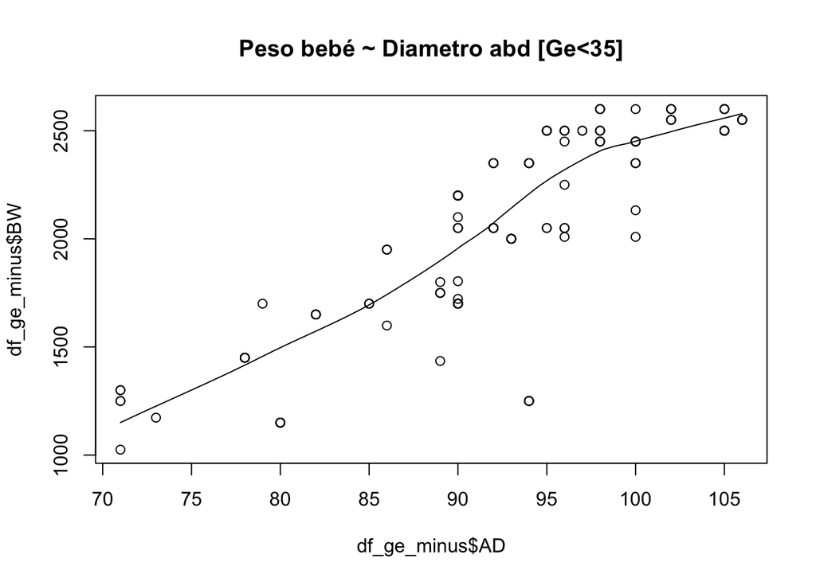

```r
scatter.smooth(x=df_ge_minus$AD, y=df_ge_minus$BW, main="Peso bebé ~ Diametro abd [Ge<35]")  # scatterplot
```

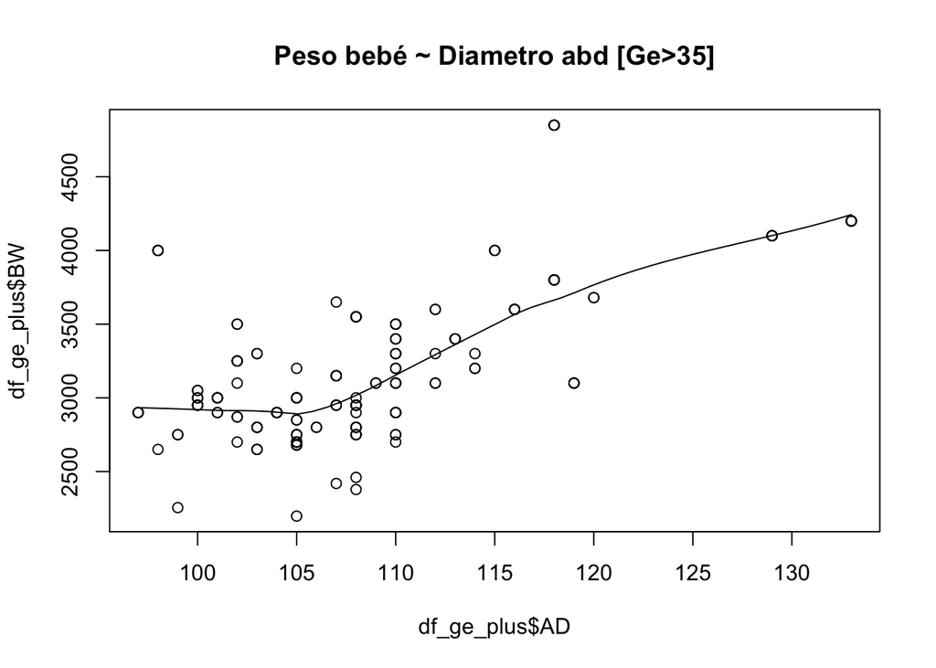

```r
scatter.smooth(x=df_ge_plus$AD, y=df_ge_plus$BW, main="Peso bebé ~ Diametro abd [Ge>35]")  # scatterplot
```

```r
multi_ge_minus <- lm(df_ge_minus$AD ~ df_ge_minus$BW, data = df_ge_minus)
summary(multi_ge_minus)
```

```
##
## Call:
## lm(formula = df_ge_minus$AD ~ df_ge_minus$BW, data = df_ge_minus)
##
## Residuals:
##     Min      1Q  Median      3Q     Max
## -9.3205 -3.9052  0.5212  2.9256 14.4773
##
## Coefficients:
##                 Estimate Std. Error t value Pr(>|t|)
## (Intercept)    5.958e+01  1.768e+00   33.70   <2e-16 ***
## df_ge_minus$BW 1.596e-02  8.481e-04   18.81   <2e-16 ***
## ---
## Signif. codes:  0 '***' 0.001 '**' 0.01 '*' 0.05 '.' 0.1 ' ' 1
##
## Residual standard error: 4.562 on 137 degrees of freedom
## Multiple R-squared:  0.721,  Adjusted R-squared:  0.7189
## F-statistic:   354 on 1 and 137 DF,  p-value: < 2.2e-16
```

Análisis peso - diametro abdominal - semanas de gestación > 35:

```r
multi_ge_plus <- lm(df_ge_plus$AD ~ df_ge_plus$BW, data = df_ge_plus)
summary(multi_ge_plus)
```

```
##
## Call:
## lm(formula = df_ge_plus$AD ~ df_ge_plus$BW, data = df_ge_plus)
##
## Residuals:
##      Min       1Q   Median       3Q      Max
## -18.3937  -3.6602   0.3731   3.4730  14.6729
##
## Coefficients:
##                Estimate Std. Error t value Pr(>|t|)
## (Intercept)   7.773e+01  3.006e+00   25.86   <2e-16 ***
## df_ge_plus$BW 9.667e-03  9.269e-04   10.43   <2e-16 ***
## ---
## Signif. codes:  0 '***' 0.001 '**' 0.01 '*' 0.05 '.' 0.1 ' ' 1
##
## Residual standard error: 6.043 on 159 degrees of freedom
## Multiple R-squared:  0.4062, Adjusted R-squared:  0.4025
## F-statistic: 108.8 on 1 and 159 DF,  p-value: < 2.2e-16
```

```r
library(magrittr)
library(dplyr)
df_ge_dic <- df_bw
df_ge_dic <- df_ge_dic %>%
      mutate(Ge = ifelse(Ge < 35,0,1))

df_ge_dic_low <- subset(df_bw, Ge = 0)
df_ge_dic_high <- subset(df_bw, Ge = 0)

multi_gedic_low <- lm(df_ge_dic_low$AD ~ df_ge_dic_low$BW, data = df_ge_dic_low)
summary(multi_gedic_low)
```

```
##
## Call:
## lm(formula = df_ge_dic_low$AD ~ df_ge_dic_low$BW, data = df_ge_dic_low)
##
## Residuals:
##     Min      1Q  Median      3Q     Max
## -20.928  -3.537   0.249   3.157  12.143
##
## Coefficients:
##                   Estimate Std. Error t value Pr(>|t|)
## (Intercept)      6.528e+01  1.188e+00   54.94   <2e-16 ***
## df_ge_dic_low$BW 1.341e-02  4.294e-04   31.23   <2e-16 ***
## ---
## Signif. codes:  0 '***' 0.001 '**' 0.01 '*' 0.05 '.' 0.1 ' ' 1
##
## Residual standard error: 5.65 on 298 degrees of freedom
## Multiple R-squared:  0.766,  Adjusted R-squared:  0.7652
## F-statistic: 975.5 on 1 and 298 DF,  p-value: < 2.2e-16
```

```r
multi_gedic_high <- lm(df_ge_dic_high$AD ~ df_ge_dic_high$BW, data = df_ge_dic_high)
summary(multi_gedic_low)
```

```
##
## Call:
## lm(formula = df_ge_dic_low$AD ~ df_ge_dic_low$BW, data = df_ge_dic_low)
##
## Residuals:
##     Min      1Q  Median      3Q     Max
## -20.928  -3.537   0.249   3.157  12.143
##
## Coefficients:
##                   Estimate Std. Error t value Pr(>|t|)
## (Intercept)      6.528e+01  1.188e+00   54.94   <2e-16 ***
## df_ge_dic_low$BW 1.341e-02  4.294e-04   31.23   <2e-16 ***
## ---
## Signif. codes:  0 '***' 0.001 '**' 0.01 '*' 0.05 '.' 0.1 ' ' 1
##
## Residual standard error: 5.65 on 298 degrees of freedom
## Multiple R-squared:  0.766,  Adjusted R-squared:  0.7652
## F-statistic: 975.5 on 1 and 298 DF,  p-value: < 2.2e-16
```

1.4. Diagnosis del modelo

Se tomará el modelo del apartado 1.2, que relaciona el peso del bebé en función del diámetro abdominal y eldiámetro biparietal.Para la diagnosis de este modelo se harán dos gráficos: uno con los valores ajustados frente a los residuos (que nos permitirá ver si la varianza es constante) y el gráfico cuantil-cuantil que compara los residuos del modelo con los valores de una variable que se distribuye normalmente(QQ plot).

Explicar conclusiones, a partir de los gráficos obtenidos.

Respuesta:

Un posible solución sería acotar el rango en el que actua la función para aumentar su predicibilidad. En el gráfico Normal Q-Q del modelo desarrollado, se observa que la zona comprendida entre -1,5 y +1,5 del eje que representa los cuartiles teóricos representa unos datos más homogeneos en cuanto a su distribución normal. Es por ello que mediante un análisis de rangos (aumento de la sensibilidad del método) se podría determinar el valor mínimo y máximo a partir de los cuales el valor predictivo del modelo deja de ser válido. Es posible que para un rango de pesos concreto encontrasemos un ajuste de bondad mayor. Esta propuesta se deja planteada pero no se desarrollará ya que, en mi opinión, excede el objetivo de la práctica :).

Modelo de regresión logística

2.1. Estimación de OR (Odds Ratio)

a1) bajo peso vs madre fumadora

Se considera bajo peso BW<2,5kg

TABLA DE CONTINGENCIA:

```r
df_bw_yes_low <- subset(df_bw, BW < 2500 & Sm == "S")
df_bw_no_low <- subset(df_bw, BW < 2500 & Sm == "N")
df_bw_yes_high <- subset(df_bw, BW >= 2500 & Sm == "S")
df_bw_no_high <- subset(df_bw, BW >= 2500 & Sm == "N")

con1 <- nrow(df_bw_yes_low)
con2 <- nrow(df_bw_no_low)
con3 <- nrow(df_bw_yes_high)
con4 <- nrow(df_bw_no_high)

cont_table_fn <- function(con1, con2, con3, con4)
  {
  table_1 <- matrix(c(con1, con2, con3, con4), ncol=2, byrow=T)
  colnames(table_1) <- c("Variable 1 TRUE", "Variable 1 FALSE")
  rownames(table_1) <- c("Peso < 2,5kg", "Peso > 2,5kg")
  table <- as.table(table_1)
  tab <- cbind(table_1, Total = rowSums(table_1))
  cont_table <- rbind(tab, Total = colSums(tab))
  print(cont_table)}

table_1 <- cont_table_fn(con1, con2, con3, con4)
```

```
##              Variable 1 TRUE Variable 1 FALSE Total
## Peso < 2,5kg              60               47   107
## Peso > 2,5kg               2              191   193
## Total                     62              238   300
```

```r
chisq.test(table_1)
```

```
##
##  Pearson's Chi-squared test
##
## data:  table_1
## X-squared = 127.18, df = 4, p-value < 2.2e-16
```

###### ODD-RATIO

```r
odd_ratio_fn <- function(p)
  {
  odd_ratio <-  p/(1-p)
  return(odd_ratio)
  }

#odd ratio de peso bajo, fumadora
p1 = table_1[1]/table_1[7]
or_1 <- odd_ratio_fn(p1)
#odd ratio de peso bajo, no fumadora
p2 = table_1[4]/table_1[7]
or_2 <- odd_ratio_fn(p2)
#odd ratio de peso alto, fumadora
p3 = table_1[2]/table_1[8]
or_3 <- odd_ratio_fn(p3)
#odd ratio de peso alto, no fumadora
p4 = table_1[5]/table_1[8]
or_4 <- odd_ratio_fn(p4)
```

```r
OR_table <- function(or1, or2, or3, or4)
  {
  table_1 <- matrix(c(or1, or2, or3, or4), ncol=2, byrow=T)
  colnames(table_1) <- c("Variable 1 TRUE", "Variable 1 FALSE")
  rownames(table_1) <- c("Peso < 2,5kg", "Peso > 2,5kg")
  table <- as.table(table_1)
  return(table)}
OR_table(or_1, or_2, or_3, or_4)
```

```
##              Variable 1 TRUE Variable 1 FALSE
## Peso < 2,5kg       1.2765957        0.7833333
## Peso > 2,5kg       0.0104712       95.5000000
```

El ratio de la probabilidad es directamente proporcional a la ocurrencia del evento estudiado. Un odd-ratio > 1 indica que es probable que se cumpla el valor que se estudia de una variable cuando está en presencia de otra variable. Así, odd-ratio nos da la información de cuán fuertemente están relacionadas unas variables con otras.

Madre fumadora tiene un odd-ratio=1,28 (OR>1). Por tanto la probabilidad en ocurrencia de tener un bebé que pese menos de 2,5kg en una madre fumadora es alta.

a2) bajo peso vs sexo

##### TABLA CONTINGENCIA

```r
df_bw_F_low <- subset(df_bw, BW < 2500 & Sex == "F")
df_bw_M_low <- subset(df_bw, BW < 2500 & Sex == "M")
df_bw_F_high <- subset(df_bw, BW >= 2500 & Sex == "F")
df_bw_M_high <- subset(df_bw, BW >= 2500 & Sex == "M")

con1_sex <- nrow(df_bw_F_low)
con2_sex <- nrow(df_bw_M_low)
con3_sex <- nrow(df_bw_F_high)
con4_sex <- nrow(df_bw_M_high)

table_2 <- cont_table_fn(con1_sex, con2_sex, con3_sex, con4_sex)
```

```
##              Variable 1 TRUE Variable 1 FALSE Total
## Peso < 2,5kg              56               51   107
## Peso > 2,5kg             112               81   193
## Total                    168              132   300
```

```r
chisq.test(table_2)
```

```
##
##  Pearson's Chi-squared test
##
## data:  table_2
## X-squared = 0.90597, df = 4, p-value = 0.9237
```

p-value es mas grande de 0,05. Esto implica aceptar la hipótesis nula, en la que se postula que las varianzas de ambos sets de datos son iguales. Por tanto, no se puede realizar una comparación de ocurrencia (numero de casos con un determinado peso en función del sexo) ya que son variables dependientes.

###### ODD RATIO

```r
#odd ratio de peso bajo, niña
p1_2 = table_2[1]/table_2[7]
or_1_2 <- odd_ratio_fn(p1_2)
#odd ratio de peso bajo, niño
p2_2 = table_2[4]/table_2[7]
or_2_2 <- odd_ratio_fn(p2_2)
#odd ratio de peso alto, niña
p3_2 = table_2[2]/table_2[8]
or_3_2 <- odd_ratio_fn(p3_2)
#odd ratio de peso alto, niño
p4_2 = table_2[5]/table_2[8]
or_4_2 <- odd_ratio_fn(p4_2)

OR_table(or_1_2, or_2_2, or_3_2, or_4_2)
```

```
##              Variable 1 TRUE Variable 1 FALSE
## Peso < 2,5kg       1.0980392        0.9107143
## Peso > 2,5kg       1.3827160        0.7232143
```

Se calcula el OR a modo de ejemplo, sin ánimo de interpretar la relación de ocurrencia entre las variables. Se observa que OR>1 para las niñas tanto en peso <2,5kg y >2,5kg. Este dato carece de sentido ya que tiene una ocurrencia similar dos parámetros contrarios. Es por ello que no tiene sentido el análisis de las OR en este caso particular.

a3) semanas de gestación (Ge), (Se dividirá entre menor y mayor o igual de 35 semanas)

```r
#dataframe con Ge como variable dicotómica
df_ge_dic
```

[output not shown]

[output cut: 587 more lines]

```r
#ge=0 bajo peso, ge=1 peso alto.

df_bw_Ge_0 <- subset(df_ge_dic, BW < 2500 & Ge == 0)
df_bw_Ge_1 <- subset(df_ge_dic, BW < 2500 & Ge == 1)
df_bw_Ge_high_0 <- subset(df_ge_dic, BW >= 2500 & Ge == 0)
df_bw_Ge_high_1 <- subset(df_ge_dic, BW >= 2500 & Ge == 1)

con1_Ge <- nrow(df_bw_Ge_0)
con2_Ge <- nrow(df_bw_Ge_1)
con3_Ge <- nrow(df_bw_Ge_high_0)
con4_Ge <- nrow(df_bw_Ge_high_1)

table_3 <- cont_table_fn(con1_Ge, con2_Ge, con3_Ge, con4_Ge)
```

```
##              Variable 1 TRUE Variable 1 FALSE Total
## Peso < 2,5kg             102                5   107
## Peso > 2,5kg              37              156   193
## Total                    139              161   300
```

```r
chisq.test(table_3)
```

```
##
##  Pearson's Chi-squared test
##
## data:  table_3
## X-squared = 160.56, df = 4, p-value < 2.2e-16
```

Se confirma H1, hipotesis en la que se plantea que las varianzas de ambos conjuntos de datos son significativamente diferentes y por lo tanto son variables independientes.

#### ODD RATIO ####

```r
#odd ratio de peso bajo, Ge<35
p1_3 = table_3[1]/table_3[7]
or_1_3 <- odd_ratio_fn(p1_3)
#odd ratio de peso bajo, Ge>35
p2_3 = table_3[4]/table_3[7]
or_2_3 <- odd_ratio_fn(p2_3)
#odd ratio de peso alto, Ge<35
p3_3 = table_3[2]/table_3[8]
or_3_3 <- odd_ratio_fn(p3_3)
#odd ratio de peso alto, Ge>35
p4_3 = table_3[5]/table_3[8]
or_4_3 <- odd_ratio_fn(p4_3)

OR_table(or_1_3, or_2_3, or_3_3, or_4_3)
```

```
##              Variable 1 TRUE Variable 1 FALSE
## Peso < 2,5kg     20.40000000       0.04901961
## Peso > 2,5kg      0.23717949       4.21621622
```

Se observa que hay una fuerte relación (OR >> 1)entre un bebé con menos de 35 semanas de gestación, como cabía esperar. Por otra parte, también se observa una mayor ocurrencia que los bebés con más semanas de gestación presenten pesos mayores o iguales a 2,5kg.

2. Si no se hubiese recodificado la variable semanas de gestación, ¿podríamos seguir el procedimiento anterior para el cálculo de la OR?. Explicar la respuesta.

No, porque la comparación de variables mediante una tabla de contingencia aplica para variables categóricas y no continuas.

3. Si queremos ver la relación entre bajo peso y lugar de procedencia, ¿podríamos seguir el procedimiento anterior para el cálculo de la OR? En el caso que la respuesta fuese negativa, ¿cuál sería una solución?.

Podriamos seguir el anterior procedimiento comparando el peso del bebé con cada país y determinar una relación ponderada entre los diferentes parámetros demográficos y sociales relevantes en cada país. Para realizar un análisis conjunto de la misma variable y países diferentes, previamente se tendrá que haber construido un marco interpretativo común en la que se pueda comparar los datos de los bebés, ya que si no fuese así, se podría realizar una comparación sesgada.

Una vez constriudo el marco común, habria que limpiar los datos, normalizarlos y asegurarse que los datos restantes representen una muestra (N) lo suficientemente grande para llegar a una conlcusión feaciente.

Realmente es un análisis complicado, ya que cuando se trata de factores fisiológicos humanos, solo determinar las variables independientes en cada grupo de población es ya en si mismo todo un reto.

2.2. Modelo de regresión logística

1. Estimar el modelo de regresión logística tomando como variable dependiente, tener bajo peso al nacer o no y siendo la variable explicativa, fumar o no. ¿Podemos considerar que el hecho de fumar es un factor de riesgo de bajo peso? Justifica tu respuesta. ¿Tiene relación con lo obtenido en el apartado anterior?

```r
df_logit <- df_bw

library(dplyr)
df_logit <- df_logit %>%
      mutate(BW = ifelse(BW < 2500,0,1)) #Se configura la variable dependiente como 0, 1 para poder realizar el ajuste de regresión logística.
df_logit <- df_logit %>%
      mutate(Ge = ifelse(Ge < 35,0,1))

RLOG_a <- glm(formula = BW~Sm, df_logit, family = binomial(link = "logit"))

summary(RLOG_a)
```

```
##
## Call:
## glm(formula = BW ~ Sm, family = binomial(link = "logit"), data = df_logit)
##
## Deviance Residuals:
##     Min       1Q   Median       3Q      Max
## -1.8012  -0.2561   0.6633   0.6633   2.6207
##
## Coefficients:
##             Estimate Std. Error z value Pr(>|z|)
## (Intercept)   1.4021     0.1628   8.611  < 2e-16 ***
## SmS          -4.8033     0.7370  -6.517 7.16e-11 ***
## ---
## Signif. codes:  0 '***' 0.001 '**' 0.01 '*' 0.05 '.' 0.1 ' ' 1
##
## (Dispersion parameter for binomial family taken to be 1)
##
##     Null deviance: 390.89  on 299  degrees of freedom
## Residual deviance: 254.19  on 298  degrees of freedom
## AIC: 258.19
##
## Number of Fisher Scoring iterations: 6
```

```r
#Estadístico de prueba

with(RLOG_a, null.deviance-deviance)
```

```
## [1] 136.6965
```

Test de significancia: chi cuadrado

Ho: modelo no sig H1: modelo si sig

```r
#valor p del estadístico de prueba
with(RLOG_a, pchisq(null.deviance-deviance, df.null-df.residual, lower.tail=FALSE))
```

```
## [1] 1.405018e-31
```

Como p-value es menor al valor tabulado, se acepta H1 y el modelo se considera significativo.

Para evaluar en qué medida afecta la variable Sm, hay que hacer el análsis de los coeficientes. El modelo nos devuelve los coeficientes en su modo logarítmico. Para interpretarlos sobre 1, se tiene que calcular la exponencial de dichos factores.

```r
#Cálculo de Odd Ratio con los coeficientes de la ecuación de regresión logística
exp(coefficients(RLOG_a))
```

```
## (Intercept)         SmS
## 4.063829787 0.008202443
```

Cuando exp(coeficient) < 1, significa que la probabilidad de obtener un bebe con peso mayor a 2,5kg es baja. Cuanto más alejado esta el valor obtenido, menor es la probabilidad de éxito. En este caso, el valor obtenido es 0.008, lo que significa que la probabilidad de obtener un bebé con >2.5kg es muy baja si la madre es fumadora.

2. Añadimos al modelo anterior las variable continua diámetro abdominal (AD). ¿Se observa una mejora del modelo? Explicar. Realizad también el cálculo de las OR y su intervalo de confianza.

```r
RLOG_b <- glm(formula = BW~AD+Sm, df_logit, family = binomial(link = "logit"))

summary(RLOG_b)
```

```
##
## Call:
## glm(formula = BW ~ AD + Sm, family = binomial(link = "logit"),
##     data = df_logit)
##
## Deviance Residuals:
##      Min        1Q    Median        3Q       Max
## -1.99501  -0.00807   0.04501   0.15867   2.37085
##
## Coefficients:
##              Estimate Std. Error z value Pr(>|z|)
## (Intercept) -48.67005    7.31254  -6.656 2.82e-11 ***
## AD            0.50513    0.07516   6.721 1.80e-11 ***
## SmS          -5.60171    1.19523  -4.687 2.78e-06 ***
## ---
## Signif. codes:  0 '***' 0.001 '**' 0.01 '*' 0.05 '.' 0.1 ' ' 1
##
## (Dispersion parameter for binomial family taken to be 1)
##
##     Null deviance: 390.89  on 299  degrees of freedom
## Residual deviance: 102.03  on 297  degrees of freedom
## AIC: 108.03
##
## Number of Fisher Scoring iterations: 8
```

Test de significancia: chi cuadrado

Ho: modelo no sig H1: modelo si sig

```r
#Estadístico de prueba

with(RLOG_b, null.deviance-deviance)
```

```
## [1] 288.8519
```

```r
#valor p del estadístico de prueba
with(RLOG_b, pchisq(null.deviance-deviance, df.null-df.residual, lower.tail=FALSE))
```

```
## [1] 1.890609e-63
```

Se rechaza Ho. El modelo es significativo.

#### ODD RATIO

```r
exp(coefficients(RLOG_b))
```

```
##  (Intercept)           AD          SmS
## 7.292357e-22 1.657202e+00 3.691557e-03
```

OR(AD)=1,66 OR(Sm)=0,004

3. Ahora añadimos al modelo anterior las variable City. Se tomará como ciudad de referencia Barcelona. Cálculo de las OR. ¿Se observa una mejora del modelo? Explicar.

```r
RLOG_c <- glm(formula = BW~AD+Sm+City, df_logit, family = binomial(link = "logit"))

summary(RLOG_c)
```

```
##
## Call:
## glm(formula = BW ~ AD + Sm + City, family = binomial(link = "logit"),
##     data = df_logit)
##
## Deviance Residuals:
##      Min        1Q    Median        3Q       Max
## -2.03336  -0.00579   0.02980   0.14267   2.50940
##
## Coefficients:
##               Estimate Std. Error z value Pr(>|z|)
## (Intercept)  -51.80837    8.15764  -6.351 2.14e-10 ***
## AD             0.53740    0.08429   6.376 1.82e-10 ***
## SmS           -5.82647    1.26686  -4.599 4.24e-06 ***
## CityGranada    0.93276    1.04358   0.894    0.371
## CityMadrid    -0.28501    0.67765  -0.421    0.674
## CityPamplona   0.76638    0.92333   0.830    0.407
## CitySevilla   -0.45828    1.12195  -0.408    0.683
## CityValencia  -0.40317    0.87323  -0.462    0.644
## ---
## Signif. codes:  0 '***' 0.001 '**' 0.01 '*' 0.05 '.' 0.1 ' ' 1
##
## (Dispersion parameter for binomial family taken to be 1)
##
##     Null deviance: 390.886  on 299  degrees of freedom
## Residual deviance:  99.519  on 292  degrees of freedom
## AIC: 115.52
##
## Number of Fisher Scoring iterations: 8
```

Test de significancia: chi cuadrado

Ho: modelo no sig H1: modelo si sig

```r
#Estadístico de prueba

with(RLOG_b, null.deviance-deviance)
```

```
## [1] 288.8519
```

```r
#valor p del estadístico de prueba
with(RLOG_b, pchisq(null.deviance-deviance, df.null-df.residual, lower.tail=FALSE))
```

```
## [1] 1.890609e-63
```

Se rechaza Ho. El modelo es significativo.

```r
exp(coefficients(RLOG_c))
```

```
##  (Intercept)           AD          SmS  CityGranada   CityMadrid
## 3.161644e-23 1.711557e+00 2.948455e-03 2.541524e+00 7.520040e-01
## CityPamplona  CitySevilla CityValencia
## 2.151961e+00 6.323735e-01 6.681991e-01
```

ODD RATIOS:

AD = 1.71 Sm = 0,003

Granada = 2,54 Madrid = 0,75 Pamplona = 2,15 Sevilla = 0,63 Valencia = 0,67

Granada y Pamplona tienen un OR>1. Esto significa que los bebés nacidos en estas ciudades tienen más probabilidades de tener un peso >2,5kg segun el modelo. Por otro lado, Madrid, Sevilla y Valencia tienen un OR<1, con lo que la probabilidad de éxito, aunque proporcional, es baja.